# Formative Assessment 4

DSC1105 Exploratory Data Analysis

Sindayen, Lorenzo Danilo V.

2026-03-23

# Dataset

The dataset that will be used in this report contains chemical measurements of red and white wines. In the previous dataset, the objective was to predict wine quality, for this report the primary focus lies on identifying the difference between red and white wine types.

For this report the variables total_sulfur_dioxide and density were identified to be the primary predictors.

```r
red_wine <- read.csv("https://archive.ics.uci.edu/ml/machine-learning-databases/wine-quality/winequality-red.csv", sep = ";")
white_wine <- read.csv("https://archive.ics.uci.edu/ml/machine-learning-databases/wine-quality/winequality-white.csv", sep = ";")

red_wine$type <- "red"
white_wine$type <- "white"

wine <- rbind(red_wine, white_wine)

names(wine) <- gsub("\\.", "_", names(wine))
```

# Data Inspection

## Structure of the Dataset

```r
class(wine)
```

```
## [1] "data.frame"
```

## First 6 observations of the Dataset

```r
head(wine)
```

|  | fixed_acidity | volatile_acidity | citric_acid | residual_sugar | chlorides | free_sulfur_dioxide | total_sulfur_dioxide | density | pH | sulphates | alcohol | quality | type |
| --- | --- | --- | --- | --- | --- | --- | --- | --- | --- | --- | --- | --- | --- |
| 1 | 7.4 | 0.70 | 0.00 | 1.9 | 0.076 | 11 | 34 | 0.9978 | 3.51 | 0.56 | 9.4 | 5 | red |
| 2 | 7.8 | 0.88 | 0.00 | 2.6 | 0.098 | 25 | 67 | 0.9968 | 3.20 | 0.68 | 9.8 | 5 | red |
| 3 | 7.8 | 0.76 | 0.04 | 2.3 | 0.092 | 15 | 54 | 0.9970 | 3.26 | 0.65 | 9.8 | 5 | red |
| 4 | 11.2 | 0.28 | 0.56 | 1.9 | 0.075 | 17 | 60 | 0.9980 | 3.16 | 0.58 | 9.8 | 6 | red |
| 5 | 7.4 | 0.70 | 0.00 | 1.9 | 0.076 | 11 | 34 | 0.9978 | 3.51 | 0.56 | 9.4 | 5 | red |
| 6 | 7.4 | 0.66 | 0.00 | 1.8 | 0.075 | 13 | 40 | 0.9978 | 3.51 | 0.56 | 9.4 | 5 | red |

## Summary of the Dataset

```r
summary(wine)
```

```
##  fixed_acidity    volatile_acidity  citric_acid     residual_sugar
##  Min.   : 3.800   Min.   :0.0800   Min.   :0.0000   Min.   : 0.600
##  1st Qu.: 6.400   1st Qu.:0.2300   1st Qu.:0.2500   1st Qu.: 1.800
##  Median : 7.000   Median :0.2900   Median :0.3100   Median : 3.000
##  Mean   : 7.215   Mean   :0.3397   Mean   :0.3186   Mean   : 5.443
##  3rd Qu.: 7.700   3rd Qu.:0.4000   3rd Qu.:0.3900   3rd Qu.: 8.100
##  Max.   :15.900   Max.   :1.5800   Max.   :1.6600   Max.   :65.800
##    chlorides       free_sulfur_dioxide total_sulfur_dioxide    density
##  Min.   :0.00900   Min.   :  1.00      Min.   :  6.0        Min.   :0.9871
##  1st Qu.:0.03800   1st Qu.: 17.00      1st Qu.: 77.0        1st Qu.:0.9923
##  Median :0.04700   Median : 29.00      Median :118.0        Median :0.9949
##  Mean   :0.05603   Mean   : 30.53      Mean   :115.7        Mean   :0.9947
##  3rd Qu.:0.06500   3rd Qu.: 41.00      3rd Qu.:156.0        3rd Qu.:0.9970
##  Max.   :0.61100   Max.   :289.00      Max.   :440.0        Max.   :1.0390
##        pH          sulphates         alcohol         quality
##  Min.   :2.720   Min.   :0.2200   Min.   : 8.00   Min.   :3.000
##  1st Qu.:3.110   1st Qu.:0.4300   1st Qu.: 9.50   1st Qu.:5.000
##  Median :3.210   Median :0.5100   Median :10.30   Median :6.000
##  Mean   :3.219   Mean   :0.5313   Mean   :10.49   Mean   :5.818
##  3rd Qu.:3.320   3rd Qu.:0.6000   3rd Qu.:11.30   3rd Qu.:6.000
##  Max.   :4.010   Max.   :2.0000   Max.   :14.90   Max.   :9.000
##      type
##  Length:6497
##  Class :character
##  Mode  :character
##
##
##
```

## Dataset structure

```r
str(wine)
```

```
## 'data.frame':    6497 obs. of  13 variables:
##  $ fixed_acidity       : num  7.4 7.8 7.8 11.2 7.4 7.4 7.9 7.3 7.8 7.5 ...
##  $ volatile_acidity    : num  0.7 0.88 0.76 0.28 0.7 0.66 0.6 0.65 0.58 0.5 ...
##  $ citric_acid         : num  0 0 0.04 0.56 0 0 0.06 0 0.02 0.36 ...
##  $ residual_sugar      : num  1.9 2.6 2.3 1.9 1.9 1.8 1.6 1.2 2 6.1 ...
##  $ chlorides           : num  0.076 0.098 0.092 0.075 0.076 0.075 0.069 0.065 0.073 0.071 ...
##  $ free_sulfur_dioxide : num  11 25 15 17 11 13 15 15 9 17 ...
##  $ total_sulfur_dioxide: num  34 67 54 60 34 40 59 21 18 102 ...
##  $ density             : num  0.998 0.997 0.997 0.998 0.998 ...
##  $ pH                  : num  3.51 3.2 3.26 3.16 3.51 3.51 3.3 3.39 3.36 3.35 ...
##  $ sulphates           : num  0.56 0.68 0.65 0.58 0.56 0.56 0.46 0.47 0.57 0.8 ...
##  $ alcohol             : num  9.4 9.8 9.8 9.8 9.4 9.4 9.4 10 9.5 10.5 ...
##  $ quality             : int  5 5 5 6 5 5 5 7 7 5 ...
##  $ type                : chr  "red" "red" "red" "red" ...
```

# Data Cleaning

## Removing Outliers in Density

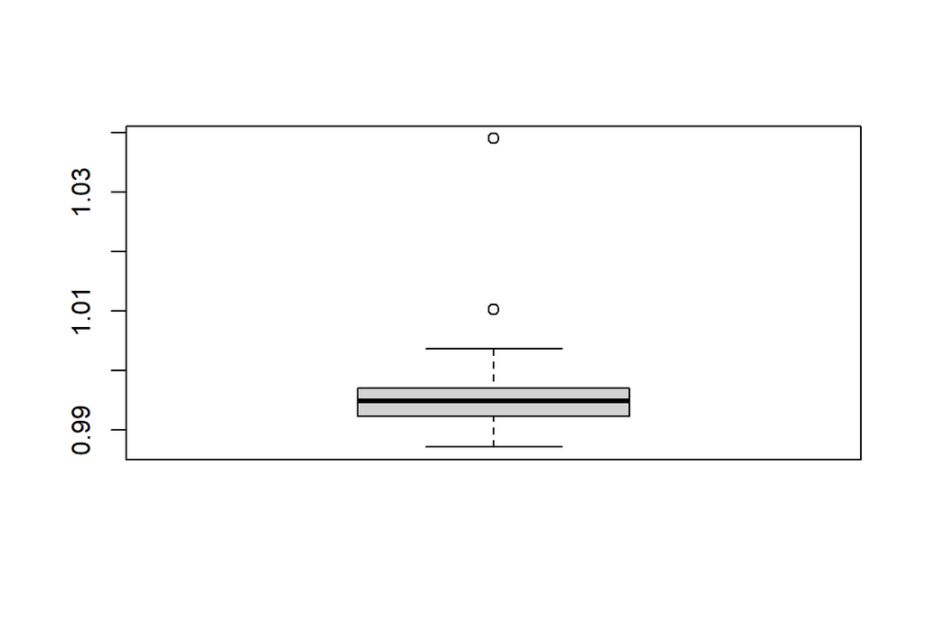

```r
boxplot(wine$density)
```

```r
Q1 <- quantile(wine$density, 0.25)
Q3 <- quantile(wine$density, 0.75)
IQR_val <- IQR(wine$density)

lower_bound <- Q1 - 1.5 * IQR_val
upper_bound <- Q3 + 1.5 * IQR_val

wine_clean <- wine %>%
  filter(density >= lower_bound & density <= upper_bound)
```

# Exploratory Data Analysis

## Variable Identification

Response variable: wine type (converted to binary)

Primary explanatory variables:

-total_sulfur_dioxide -density

## Convert Wine Type to Binary

```r
wine_clean$type_binary <- ifelse(wine_clean$type == "white", 1, 0)
```

## Scatterplot: Wine Type vs Total Sulfur Dioxide

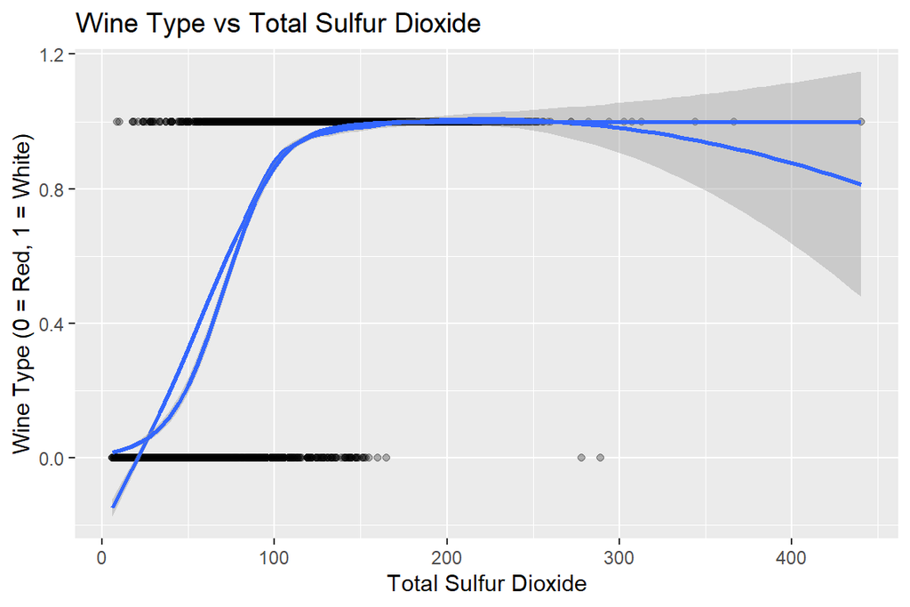

```r
ggplot(wine_clean, aes(x = total_sulfur_dioxide, y = type_binary)) +
  geom_point(alpha = 0.3) +
  geom_smooth(method = "loess") +
  geom_smooth(method = "glm", method.args = list(family = "binomial")) +
  labs(
    title = "Wine Type vs Total Sulfur Dioxide",
    x = "Total Sulfur Dioxide",
    y = "Wine Type (0 = Red, 1 = White)"
  )
```

Interpretation: The LOESS smoother captures local trends in the data, while the logistic regression smoother gives a more objective interpretation. Differences between the curves indicate potential non-linearity in the relationship.

## Scatterplot: Wine Type vs Density

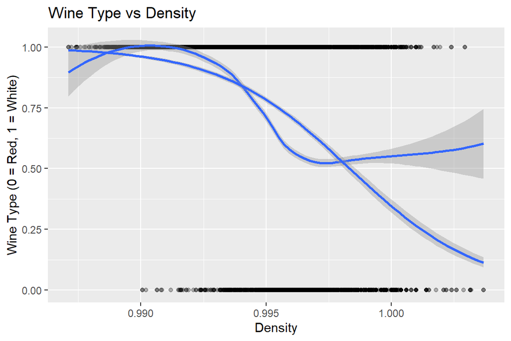

```r
ggplot(wine_clean, aes(x = density, y = type_binary)) +
  geom_point(alpha = 0.3) +
  geom_smooth(method = "loess") +
  geom_smooth(method = "glm", method.args = list(family = "binomial")) +
  labs(
    title = "Wine Type vs Density",
    x = "Density",
    y = "Wine Type (0 = Red, 1 = White)"
  )
```

# Logistic Regression Models

## Model 1: No Interaction

```r
model1 <- glm(type_binary ~ density + total_sulfur_dioxide,
              data = wine_clean,
              family = "binomial")

summary(model1)
```

```
##
## Call:
## glm(formula = type_binary ~ density + total_sulfur_dioxide, family = "binomial",
##     data = wine_clean)
##
## Coefficients:
##                        Estimate Std. Error z value Pr(>|z|)
## (Intercept)           802.43997   32.60225   24.61   <2e-16 ***
## density              -811.91260   32.86373  -24.70   <2e-16 ***
## total_sulfur_dioxide    0.07291    0.00230   31.70   <2e-16 ***
## ---
## Signif. codes:  0 '***' 0.001 '**' 0.01 '*' 0.05 '.' 0.1 ' ' 1
##
## (Dispersion parameter for binomial family taken to be 1)
##
##     Null deviance: 7249.3  on 6493  degrees of freedom
## Residual deviance: 1607.5  on 6491  degrees of freedom
## AIC: 1613.5
##
## Number of Fisher Scoring iterations: 7
```

## Model 2: With Interaction

```r
model2 <- glm(type_binary ~ density * total_sulfur_dioxide,
              data = wine_clean,
              family = "binomial")

summary(model2)
```

```
##
## Call:
## glm(formula = type_binary ~ density * total_sulfur_dioxide, family = "binomial",
##     data = wine_clean)
##
## Coefficients:
##                               Estimate Std. Error z value Pr(>|z|)
## (Intercept)                   1646.544    108.283  15.206   <2e-16 ***
## density                      -1660.289    108.905 -15.245   <2e-16 ***
## total_sulfur_dioxide            -8.578      1.004  -8.545   <2e-16 ***
## density:total_sulfur_dioxide     8.691      1.009   8.612   <2e-16 ***
## ---
## Signif. codes:  0 '***' 0.001 '**' 0.01 '*' 0.05 '.' 0.1 ' ' 1
##
## (Dispersion parameter for binomial family taken to be 1)
##
##     Null deviance: 7249.3  on 6493  degrees of freedom
## Residual deviance: 1515.4  on 6490  degrees of freedom
## AIC: 1523.4
##
## Number of Fisher Scoring iterations: 8
```

# Coplots

## Density conditioned on Total Sulfur Dioxide

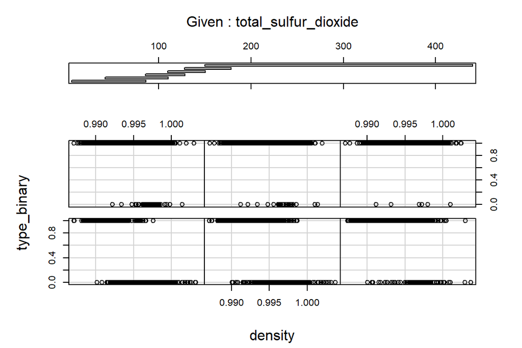

```r
coplot(type_binary ~ density | total_sulfur_dioxide, data = wine_clean)
```

## Total Sulfur Dioxide conditioned on Density

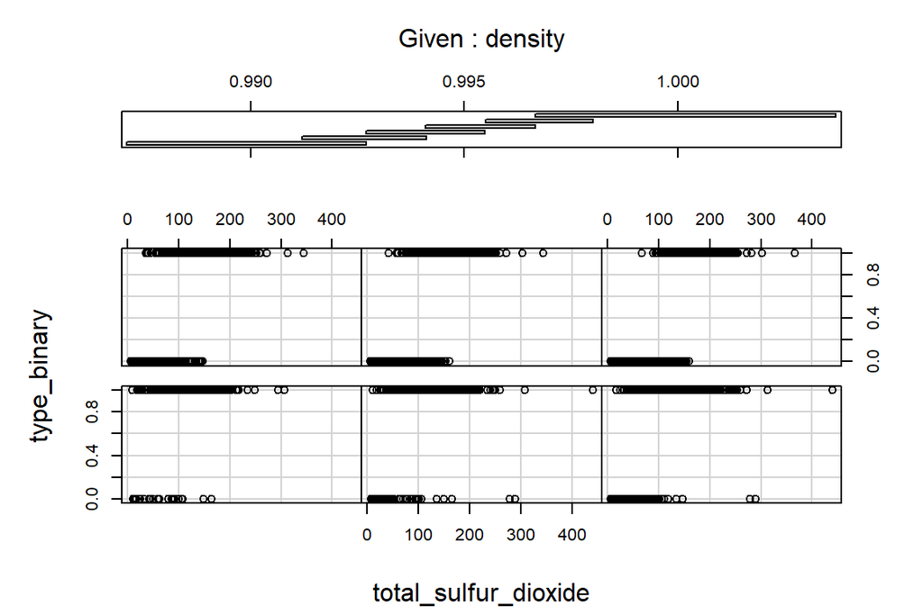

```r
coplot(type_binary ~ total_sulfur_dioxide | density, data = wine_clean)
```

## Model Comparison Interpretation

This interaction model allows the effect of density on wine type to vary depending on the level of total sulfur dioxide. This provides a more flexible model compared to the additive model without interaction.

# Reflection

In this report, the relationship between wine type and key chemical properties were analyzed to see if there is significant correlation between the two. Variables within chemical properties such as density and total sulfur dioxide were observed through the implementation of visualization and modeling technique. From the results of the models it was clear that both played a significant roles in distinguishing between red and white wines.

Additionally, the use of LOESS and logistic regression smoothers highlights both the local and global patterns in the data. Logistic regression models further quantified these relationships, showing how predictor variables influence the probability of a wine being classified as red or white.

Concluding this activity, it was shown how important the implementation of visualization and statistical modeling in understanding complex datasets.